# 108_全國夏季學院_7月15日_Class3

#### 這次會用到的資料集

#### 年度職災案例彙編 https://data.gov.tw/dataset/6644

#### 職業災害統計行業別與受傷部位統計數據 https://data.gov.tw/dataset/20592

#### 為何使用這兩組資料集?

#### 根據助教提點的兩點建議

#### 1.說明很詳盡，可以利用 Rmd 的特性在程式碼的外面寫說明，不用寫成註解

#### 2.兩個資料集沒有關聯很可惜

#### 因此學生再次尋找了兩個可能有關聯的資料集

#### 以職業災害為主題，學生曾在醫院做過志工，見過一些因為工作導致受傷的患者

#### 因此兩利用這兩個資料集嘗試分析出我們需要關注的職業災害種類，也許能對社會有幫助

#### 資料來源受限於政府開放資料集完整性(有一些下載點掛掉了)，唯有2014年的資料仍完整

#### 謝謝助教幫我把網址修正成可以正確顯示的網址，再次謝謝助教

## 預先安裝好分析環境(如果有函式庫無法導入就使用以下的程式碼)

```r
#install.packages("dplyr")
#install.packages("tidyr")
#install.packages("rvest")
#install.packages("wordcloud")
#install.packages("tidyverse")
#install.packages("ggplot2")
#install.packages("scales")
#install.packages("stringr")
#install.packages("rmarkdown")
#install.packages("rmarkdown")
#install.packages("knitr")
#install.packages("colormap")
#install.packages("wesanderson")
#install.packages("RColorBrewer")
#install.packages("treemapify")
#treemapify函式庫已經預告下個版本會合併入ggplot2內，不建議再使用
```

#### 確認安裝套件版本

```r
packageVersion("dplyr")
```

```
## [1] '0.8.3'
```

```r
packageVersion("tidyr")
```

```
## [1] '0.8.3'
```

```r
packageVersion("rvest")
```

```
## [1] '0.3.4'
```

```r
packageVersion("tidyverse")
```

```
## [1] '1.2.1'
```

```r
packageVersion("wordcloud")
```

```
## [1] '2.6'
```

```r
packageVersion("ggplot2")
```

```
## [1] '3.2.0'
```

```r
packageVersion("scales")
```

```
## [1] '1.0.0'
```

```r
packageVersion("stringr")
```

```
## [1] '1.4.0'
```

```r
packageVersion("rmarkdown")
```

```
## [1] '1.14'
```

```r
packageVersion("colormap")
```

```
## [1] '0.1.4'
```

```r
packageVersion("wesanderson")
```

```
## [1] '0.3.6'
```

```r
packageVersion("RColorBrewer")
```

```
## [1] '1.1.2'
```

```r
packageVersion("treemapify")
```

```
## [1] '2.5.3'
```

#### 顯示必要資訊

```r
R.Version()
```

```
## $platform
## [1] "x86_64-w64-mingw32"
##
## $arch
## [1] "x86_64"
##
## $os
## [1] "mingw32"
##
## $system
## [1] "x86_64, mingw32"
##
## $status
## [1] ""
##
## $major
## [1] "3"
##
## $minor
## [1] "6.1"
##
## $year
## [1] "2019"
##
## $month
## [1] "07"
##
## $day
## [1] "05"
##
## $`svn rev`
## [1] "76782"
##
## $language
## [1] "R"
##
## $version.string
## [1] "R version 3.6.1 (2019-07-05)"
##
## $nickname
## [1] "Action of the Toes"
```

```r
Sys.time()
```

```
## [1] "2019-07-18 02:18:54 CST"
```

```r
gc() # 原來R語言有記憶體清理函式，慎用...。
```

```
##           used (Mb) gc trigger (Mb) max used (Mb)
## Ncells  525981 28.1    1184017 63.3   621662 33.3
## Vcells 1008141  7.7    8388608 64.0  1600594 12.3
```

#### 導入函式庫

```r
library('dplyr')
library('tidyr')
library('rvest')
library('tidyverse') #其實只要引入tidyverse庫就不用寫前三行了，不過就當作練習
```

```r
library('wordcloud')
library('ggplot2')
library('scales')
library('stringr') #方便易用的資料前處理工具
library('RColorBrewer') #關於顏色的佈景主題
library('colormap') #關於顏色的佈景主題
library('wesanderson') #關於顏色的佈景主題
library('treemapify') #矩形式樹狀結構繪圖法
```

#### 設置工作目錄，這屬於暫時性工作目錄，會依照檔案工作目錄變化來修改

```r
setwd("C:/Users/user/Documents/GitHub/National-Summer-Academy/Week2")
```

#### 在R語言中，如果資料是帶有繁體中文的，編碼建議使用BIG-5

#### 然而UTF-8編碼目前會出錯，原因待查

#### 年度職災案例彙編，編碼為BIG-5

```r
job_disaster_case_compilation <- read.table(
    "年度職災案例彙編.csv",
    header = TRUE,
    sep = ",",
    na.strings = c(" "),
    row.names = NULL,
    fill = TRUE,
    encoding = "BIG-5",
)
```

#### 職業災害統計行業別與受傷部位統計數據，編碼為BIG-5

```r
injured_parts_statistics <- read.table(
    "職業災害統計行業別與受傷部位統計數據.csv",
    header = TRUE,
    sep = ",",
    na.strings = c(" "),
    fill = TRUE,
    encoding = "BIG-5",
)
```

#### 預先觀看年度職災案例資料外觀

```r
head(job_disaster_case_compilation)
```

```
##   縣市別       行業別         媒介物   災害類型 發生日期 死 傷
## 1 台中市       營造業             樑 墜落、滾落 2014-1-3  1  0
## 2 台中市       營造業         施工架 墜落、滾落 2014-1-4  1  0
## 3 桃園縣       營造業         施工架 墜落、滾落 2014-1-4  1  0
## 4 台南市       製造業           通路       跌倒 2014-1-7  1  0
## 5 嘉義縣       製造業           其他 被夾、被捲 2014-1-8  1  0
## 6 桃園縣 批發及零售業 其他(營建機械) 墜落、滾落 2014-1-8  1  0
```

#### 預先觀看職業災害統計行業別與受傷部位資料外觀

```r
head(injured_parts_statistics)
```

```
##   年度 受傷部位           行業別 受傷部位次數
## 1 2014       頭 農、林、漁、牧業            4
## 2 2014       頭 礦業及土石採取業            1
## 3 2014       頭       食品製造業           32
## 4 2014       頭       飲料製造業            1
## 5 2014       頭       菸草製造業            0
## 6 2014       頭           紡織業           17
```

#### 初步觀看年度職災案例資料維度

```r
summarise(
    job_disaster_case_compilation,
    observes_n = n(),
    variable_n = ncol(job_disaster_case_compilation)
)
```

```
##   observes_n variable_n
## 1        348          7
```

#### 初步觀看職業災害統計行業別與受傷部位資料維度

```r
summarise(
    injured_parts_statistics,
    observes_n = n(),
    variable_n = ncol(injured_parts_statistics)
)
```

```
##   observes_n variable_n
## 1       1080          4
```

#### 年度職災案例的日期部分比職業災害統計行業別與受傷部位還要詳細

#### 因此這邊做一次預處理

#### 將日期拿掉，只保留年份

```r
job_disaster_case_compilation$發生日期  <-
    str_sub(job_disaster_case_compilation$發生日期, 1, 4)
```

#### 觀看是否順利處理

```r
head(job_disaster_case_compilation)
```

```
##   縣市別       行業別         媒介物   災害類型 發生日期 死 傷
## 1 台中市       營造業             樑 墜落、滾落     2014  1  0
## 2 台中市       營造業         施工架 墜落、滾落     2014  1  0
## 3 桃園縣       營造業         施工架 墜落、滾落     2014  1  0
## 4 台南市       製造業           通路       跌倒     2014  1  0
## 5 嘉義縣       製造業           其他 被夾、被捲     2014  1  0
## 6 桃園縣 批發及零售業 其他(營建機械) 墜落、滾落     2014  1  0
```

#### 由於資料品質優良，基本的資料前處理先到這邊

#### 開始使用ggplot2做視覺化

#### 先觀看職業災害每個案例受傷部位大多傷在哪些部位

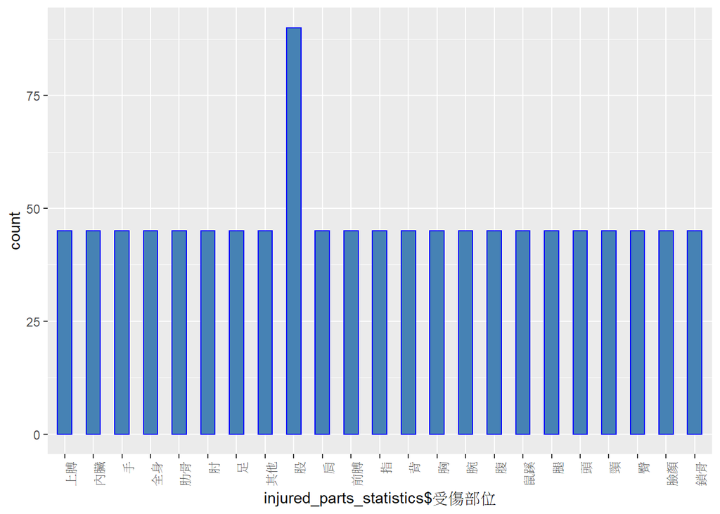

```r
#freq <- as.data.frame(table(injured_parts_statistics$受傷部位))["Freq"]
g <- ggplot(injured_parts_statistics,
            aes(x = injured_parts_statistics$受傷部位))
g + geom_bar(fill = "steelblue",
             color = "blue",
             width = 0.5) +
    theme(axis.text.x = element_text(angle = 90, hjust = 1))
```

#### 先看各地區發生「職業災害」的情況

```r
table(job_disaster_case_compilation$縣市別)
```

```
##
## 台中市 台北市 台東縣 台南市   竹科 宜蘭縣 花蓮縣 金門縣 南投縣   南科
##     52     15      4     15      1     15      6      2      6      1
## 屏東縣 苗栗縣 桃園縣 高雄市 基隆市 雲林縣 新北市 新竹市 新竹縣 經加處
##     12     14     56     47      5     13     35      3     11      2
## 嘉義市 嘉義縣 彰化縣
##      5     11     17
```

#### 閱讀過說明手冊後，作者表示qplot()用法類似內建的plot()，在功能比plot()多

#### 繪圖過程較簡單易上手，但作者還是高度建議應該好好學習ggplot()的用法，才能繪製

#### 出更複雜詳細的圖表

#### 用qplot繪製Bar Chart

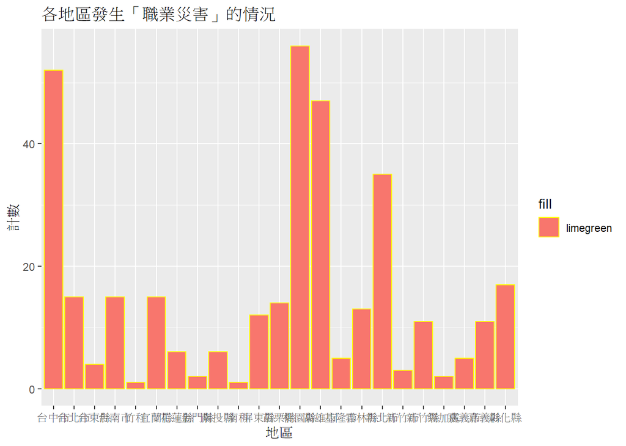

```r
g <- qplot(
    data = job_disaster_case_compilation,
    job_disaster_case_compilation$縣市別,
    main = "各地區發生「職業災害」的情況",
    xlab = "地區",
    ylab = "計數",
    geom = "bar",
    color = I("yellow"),
    fill = "limegreen"
)
g
```

#### 用ggplot繪製histogram

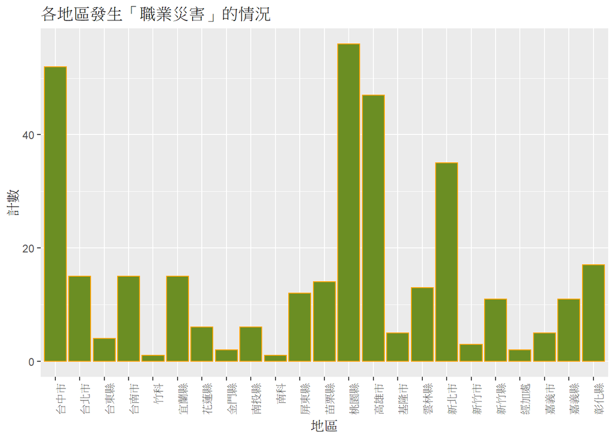

```r
g <- ggplot(data = job_disaster_case_compilation,
            aes(x = job_disaster_case_compilation$縣市別))
g + geom_histogram(stat = "count", color = "orange1",fill = "olivedrab") + xlab("地區") + ylab("計數") +
    labs(title = "各地區發生「職業災害」的情況") +
    theme(axis.text.x = element_text(angle = 90, hjust = 1))
```

#### 發生職業災害的案例統計數: 第一名桃園市，第二名台中市, 第三名高雄市

#### 找出最危險職業

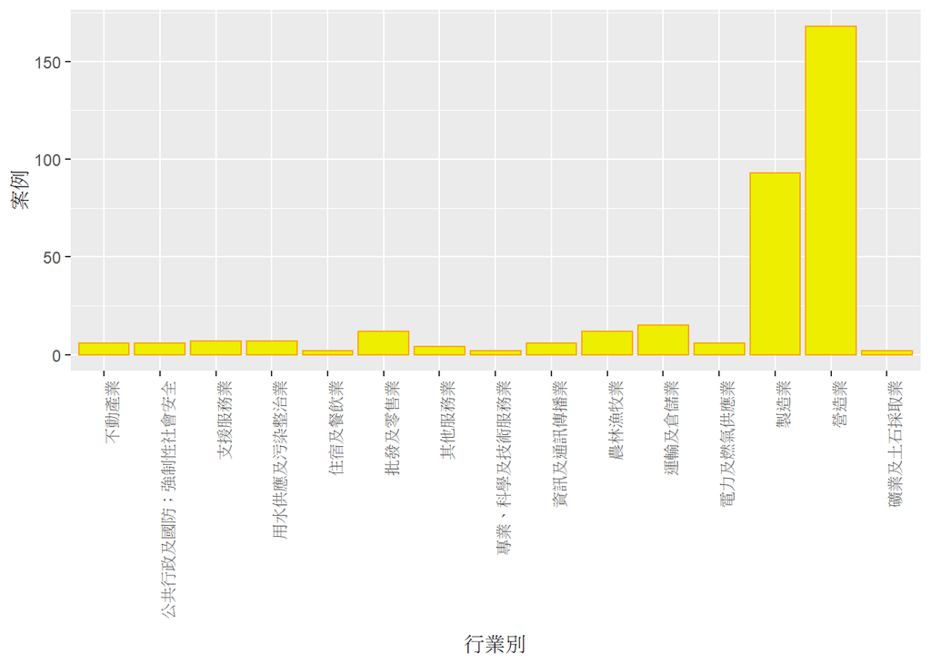

```r
top_ten_fatal <- data.frame(job_disaster_case_compilation)["行業別"]
ggplot(data = top_ten_fatal) +
    geom_bar(mapping = aes(x = top_ten_fatal$行業別), color = "orange1",
             fill = "yellow2") +
    xlab("行業別") +
    ylab("案例") +
    theme(axis.text.x = element_text(angle = 90, hjust = 1))
```

#### 營造業發生最多的職業災害，其次為製造業

#### 使用散點圖查看在台灣各地區比較流行從事何種職業

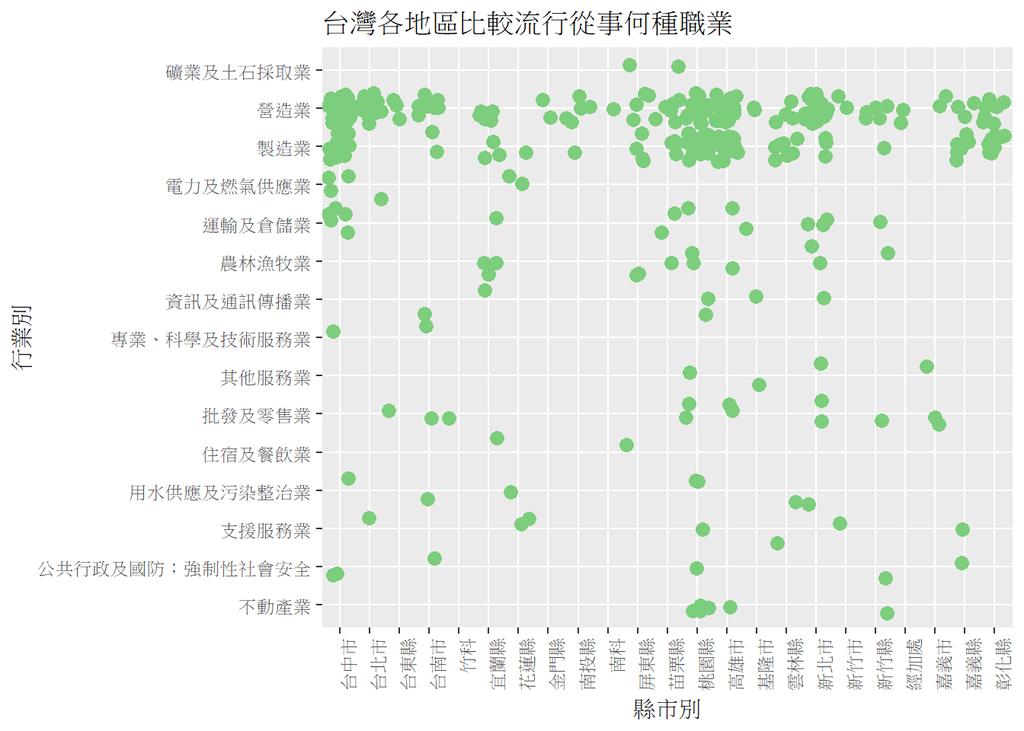

```r
g <- ggplot(
    data = job_disaster_case_compilation,
    aes(
        job_disaster_case_compilation$"縣市別",
        job_disaster_case_compilation$"行業別"
    )
)
g + xlab("縣市別") + ylab("行業別") +
    geom_jitter(size = 3, color = "palegreen3") +
    labs(title = "台灣各地區比較流行從事何種職業") +
    theme(axis.text.x = element_text(angle = 90, hjust = 1))
```

#### 繪製矩形式樹狀結構，使用新函式庫，然後這種圖畫的速度超慢

#### 各個行業容易受傷的部位與受傷的頻率

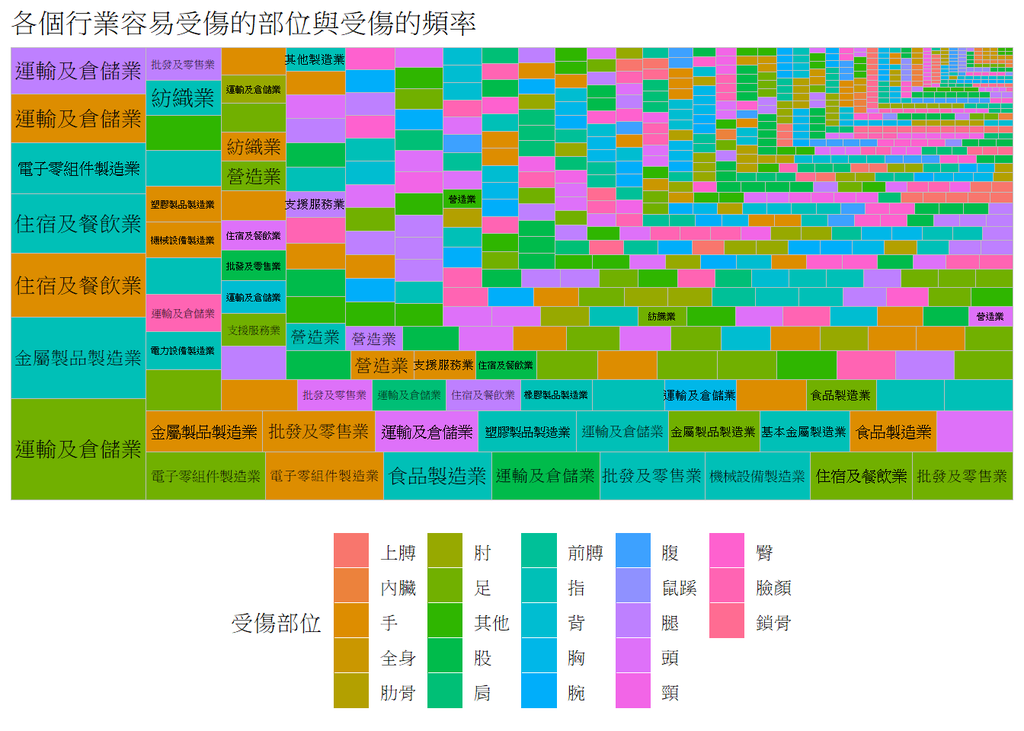

```r
g <- ggplot(
    injured_parts_statistics,
    aes(
        area = injured_parts_statistics$受傷部位次數,
        fill =  受傷部位,
        label = injured_parts_statistics$行業別
    )
)
g + geom_treemap() + geom_treemap_text(
    color = "black",
    place = "centre",
    grow = TRUE,
    reflow = TRUE
) +
    theme(legend.position = "bottom") +
    labs(title = "各個行業容易受傷的部位與受傷的頻率")
```